# Proyecto Data Science Aplicada EII7446

```r
              resultsAD <- ad.test(Data_Workable$`temperature`);resultsAD
```

```
    Anderson-Darling normality test

data:  Data_Workable$temperature
A = 3.1792, p-value = 0.00000005701
```

```r
              resultsKS <- ks.test(Data_Workable$`temperature`, "pnorm", mean(Data_Workable$`temperature`), sd(Data_Workable$`temperature`))
              #Non conclusive, not normal

          #Simple imputation: Median
              Data_Imputed$`temperature`[is.na(Data_Imputed$`temperature`)] <- median(Data_Imputed$`temperature`, na.rm = TRUE)
              summary(Data_Imputed$`temperature`)
```

```
   Min. 1st Qu.  Median    Mean 3rd Qu.    Max.
  33.25   36.29   36.65   36.68   37.02   39.13
```

```r
              summary(Data_Workable$`temperature`)
```

```
   Min. 1st Qu.  Median    Mean 3rd Qu.    Max.    NA's
  33.25   36.29   36.65   36.68   37.02   39.13      18
```

```r
      #7. SP O2----

          #12/1176
          #1.02%

          #Cor
              data_cor <- cor(Data_Workable[ , colnames(Data_Workable) != "SP_O2"],Data_Workable$SP_O2,use='complete.obs');data_cor
```

```
                                  [,1]
outcome                  -0.0348159671
age                       0.0138452485
gendera                   0.0008162841
BMI                      -0.1357740705
hypertensive              0.1352143706
atrialfibrillation        0.0449368915
CHD_with_no_MI            0.1176376349
diabetes                  0.1589109244
deficiencyanemias         0.1516087467
depression                0.0651376108
Hyperlipemia              0.0926534277
Renal_failure             0.1284910953
COPD                     -0.0874766359
heart_rate               -0.0625814860
Systolic_blood_pressure   0.0320453605
Diastolic_blood_pressure -0.1262745725
Respiratory_rate         -0.2316133180
temperature               0.0680294571
Urine_output             -0.0554201759
hematocrit               -0.3490950069
RBC                      -0.3344576917
MCH                       0.0581276297
MCHC                      0.0978802808
MCV                       0.0156420205
RDW                       0.0858882398
Leucocyte                 0.0353766521
Platelets                 0.0009330776
Neutrophils              -0.0396456940
Basophils                -0.0156610968
Lymphocyte                0.0352630835
PT                       -0.0522261287
INR                      -0.0646532278
NT_proBNP                 0.0930836271
Creatine_kinase          -0.0366935474
Creatinine                0.1428857242
Urea_nitrogen             0.0685588239
glucose                   0.0386429887
Blood_potassium          -0.0397442217
Blood_sodium             -0.0311662050
Blood_calcium            -0.0832167390
Chloride                  0.1954127377
Anion_gap                 0.0625507370
Magnesium_ion            -0.0629967289
PH                        0.0411497893
Bicarbonate              -0.2300304656
Lactic_acid               0.0896589883
PCO2                     -0.2703810251
EF                       -0.0214766762
```

```r
              #Resp: Low for all

          #Behavior
              hist(Data_Workable$SP_O2)
              qqnorm(Data_Workable$SP_O2)
```

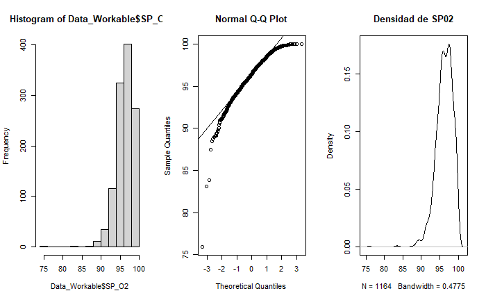

```r
              qqline(Data_Workable$SP_O2)
              dens = density(Data_Workable$SP_O2, na.rm = TRUE)
              plot(dens, main ="Densidad de SP02")
```

```r
              #Resp: Not Normal

          #Hyp. test
              resultsSW <- shapiro.test(Data_Workable$SP_O2);resultsSW
```

```
    Shapiro-Wilk normality test

data:  Data_Workable$SP_O2
W = 0.93027, p-value < 0.00000000000000022
```

```r
              resultsAD <- ad.test(Data_Workable$SP_O2);resultsAD
```

```
    Anderson-Darling normality test

data:  Data_Workable$SP_O2
A = 7.3197, p-value < 0.00000000000000022
```

```r
              resultsKS <- ks.test(Data_Workable$SP_O2, "pnorm", mean(Data_Workable$SP_O2), sd(Data_Workable$SP_O2))
              #Non conclusive, not normal

          #Simple imputation: Median
              Data_Imputed$SP_O2[is.na(Data_Imputed$SP_O2)] <- median(Data_Imputed$SP_O2, na.rm = TRUE)
              summary(Data_Imputed$SP_O2)
```

```
   Min. 1st Qu.  Median    Mean 3rd Qu.    Max.
  75.92   95.00   96.45   96.27   97.89  100.00
```

```r
              summary(Data_Workable$SP_O2)
```

```
   Min. 1st Qu.  Median    Mean 3rd Qu.    Max.    NA's
  75.92   95.00   96.45   96.27   97.92  100.00      12
```

```r
      #8. Urine----

          #35/1176
          #2.97%

          #Cor
              data_cor <- cor(Data_Workable[ , colnames(Data_Workable) != "Urine_output"],Data_Workable$Urine_output,use='complete.obs');data_cor
```

```
                                [,1]
outcome                  -0.17003027
age                      -0.25390848
gendera                  -0.09717380
BMI                       0.26706876
hypertensive             -0.05792930
atrialfibrillation       -0.19382881
CHD_with_no_MI            0.01943760
diabetes                  0.05811502
deficiencyanemias        -0.05639808
depression                0.06766967
Hyperlipemia             -0.04636291
Renal_failure            -0.09885941
COPD                     -0.04462245
heart_rate                0.04189864
Systolic_blood_pressure   0.18880731
Diastolic_blood_pressure  0.17729131
Respiratory_rate          0.10390768
temperature               0.20210255
SP_O2                    -0.05542018
hematocrit                0.13040783
RBC                       0.16810976
MCH                      -0.07244177
MCHC                      0.01427684
MCV                      -0.09663200
RDW                      -0.04165823
Leucocyte                -0.13023817
Platelets                 0.03495501
Neutrophils              -0.14526774
Basophils                 0.12599754
Lymphocyte                0.16577089
PT                       -0.02156779
INR                      -0.02523248
NT_proBNP                -0.27747152
Creatine_kinase          -0.03205200
Creatinine               -0.24158729
Urea_nitrogen            -0.23570260
glucose                  -0.02913185
Blood_potassium          -0.13060065
Blood_sodium             -0.02843229
Blood_calcium             0.12472208
Chloride                 -0.23175991
Anion_gap                -0.21802122
Magnesium_ion            -0.04734995
PH                        0.20506521
Bicarbonate               0.28911335
Lactic_acid              -0.13037350
PCO2                      0.09984323
EF                        0.03421908
```

```r
              #Resp: low for all

          #Behavior
              hist(Data_Workable$Urine_output)
              qqnorm(Data_Workable$Urine_output)
```

```r
              qqline(Data_Workable$Urine_output)
              dens = density(Data_Workable$Urine_output, na.rm = TRUE)
              plot(dens, main ="Densidad de Urine")
```

```r
              #Resp: Maybe Normal

          #Hyp. test
              resultsSW <- shapiro.test(Data_Workable$Urine_output);resultsSW
```

```
    Shapiro-Wilk normality test

data:  Data_Workable$Urine_output
W = 0.9082, p-value < 0.00000000000000022
```

```r
              resultsAD <- ad.test(Data_Workable$Urine_output);resultsAD
```

```
    Anderson-Darling normality test

data:  Data_Workable$Urine_output
A = 20.205, p-value < 0.00000000000000022
```

```r
              resultsKS <- ks.test(Data_Workable$Urine_output, "pnorm", mean(Data_Workable$Urine_output), sd(Data_Workable$Urine_output))
              #Non conclusive, not normal

          #Simple imputation: Median
              Data_Imputed$Urine_output[is.na(Data_Imputed$Urine_output)] <- median(Data_Imputed$Urine_output, na.rm = TRUE)
              summary(Data_Imputed$Urine_output)
```

```
   Min. 1st Qu.  Median    Mean 3rd Qu.    Max.
    0.0   997.2  1675.0  1892.6  2475.0  8820.0
```

```r
              summary(Data_Workable$Urine_output)
```

```
   Min. 1st Qu.  Median    Mean 3rd Qu.    Max.    NA's
      0     980    1675    1899    2500    8820      35
```

```r
      #9. Neutrophils----

          #144/1176
          #12.24%

          #Cor
              data_cor <- cor(Data_Workable[ , colnames(Data_Workable) != "Neutrophils"],Data_Workable$Neutrophils,use='complete.obs');data_cor
```

```
                                 [,1]
outcome                   0.130475977
age                       0.169823177
gendera                  -0.041212779
BMI                      -0.130751822
hypertensive             -0.012477604
atrialfibrillation        0.199910327
CHD_with_no_MI            0.098556062
diabetes                 -0.005306357
deficiencyanemias        -0.016436329
depression               -0.004148128
Hyperlipemia              0.002280610
Renal_failure            -0.024872327
COPD                      0.054064614
heart_rate                0.050465892
Systolic_blood_pressure  -0.051833196
Diastolic_blood_pressure -0.081323126
Respiratory_rate          0.075874546
temperature              -0.087535500
SP_O2                    -0.039645694
Urine_output             -0.145267735
hematocrit               -0.001517146
RBC                       0.020663849
MCH                      -0.075565223
MCHC                     -0.060323785
MCV                      -0.058473388
RDW                      -0.090182575
Leucocyte                 0.344603291
Platelets                 0.093210906
Basophils                -0.542980110
Lymphocyte               -0.915471215
PT                        0.068894876
INR                       0.060521669
NT_proBNP                 0.133182054
Creatine_kinase           0.020014992
Creatinine               -0.056848506
Urea_nitrogen             0.097453724
glucose                   0.078285139
Blood_potassium          -0.057532624
Blood_sodium              0.060763762
Blood_calcium            -0.108823730
Chloride                  0.076266884
Anion_gap                 0.040114890
Magnesium_ion             0.085820111
PH                        0.043300837
Bicarbonate              -0.049145548
Lactic_acid               0.006345958
PCO2                     -0.040272371
EF                        0.033904627
```

[figure not shown]

```r
              #Resp: Low for all, -0.915471215 for Lymphocite

          #Graph by cor
              par(mfrow=c(1,1))
```

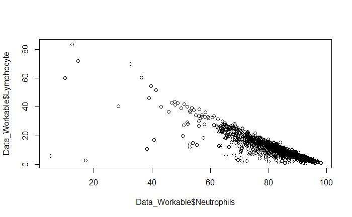

```r
              plot(x = Data_Workable$Neutrophils, y = Data_Workable$Lymphocyte)
              par(mfrow=c(1,3))
```

```r
          #Behavior
              hist(Data_Workable$`Neutrophils`)
              qqnorm(Data_Workable$`Neutrophils`)
```

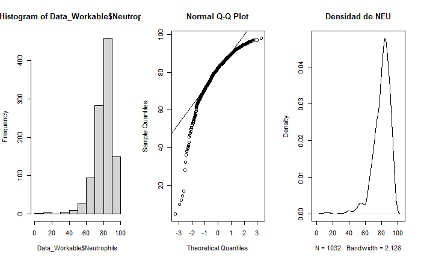

```r
              qqline(Data_Workable$`Neutrophils`)
              dens = density(Data_Workable$`Neutrophils`, na.rm = TRUE)
              plot(dens, main ="Densidad de NEU")
```

```r
              #Resp: Maybe Normal

          #Hyp. test
              resultsSW <- shapiro.test(Data_Workable$`Neutrophils`);resultsSW
```

```
    Shapiro-Wilk normality test

data:  Data_Workable$Neutrophils
W = 0.86357, p-value < 0.00000000000000022
```

```r
              resultsAD <- ad.test(Data_Workable$`Neutrophils`);resultsAD
```

```
    Anderson-Darling normality test

data:  Data_Workable$Neutrophils
A = 23.059, p-value < 0.00000000000000022
```

```r
              resultsKS <- ks.test(Data_Workable$`Neutrophils`, "pnorm", mean(Data_Workable$`Neutrophils`), sd(Data_Workable$`Neutrophils`))
              #Non conclusive, no normal

          #Simple imputation: Median
              Data_Imputed$`Neutrophils`[is.na(Data_Imputed$`Neutrophils`)] <- median(Data_Imputed$`Neutrophils`, na.rm = TRUE)
              summary(Data_Imputed$`Neutrophils`)
```

```
   Min. 1st Qu.  Median    Mean 3rd Qu.    Max.
   5.00   76.44   82.47   80.40   86.60   98.00
```

```r
              summary(Data_Workable$`Neutrophils`)
```

```
   Min. 1st Qu.  Median    Mean 3rd Qu.    Max.    NA's
   5.00   74.77   82.47   80.12   87.46   98.00     144
```

```r
          ###1.1

      #10.Basophils----

          #259/1176
          #22.02%

          #Cor
              data_cor <- cor(Data_Workable[ , colnames(Data_Workable) != "Basophils"],Data_Workable$Basophils,use='complete.obs');data_cor
```

```
                                  [,1]
outcome                  -0.0882783744
age                      -0.1169817137
gendera                  -0.0365969824
BMI                       0.0758335819
hypertensive             -0.0707304775
atrialfibrillation       -0.1630538134
CHD_with_no_MI           -0.0361081544
diabetes                 -0.0716842157
deficiencyanemias        -0.0881538827
depression               -0.0121198783
Hyperlipemia             -0.0096239537
Renal_failure            -0.0434736890
COPD                     -0.0419509366
heart_rate               -0.0144596362
Systolic_blood_pressure   0.0513698726
Diastolic_blood_pressure  0.1443267931
Respiratory_rate          0.0186874649
temperature               0.0105075807
SP_O2                    -0.0156610968
Urine_output              0.1259975432
hematocrit                0.1584458502
RBC                       0.1155334446
MCH                       0.0368397359
MCHC                     -0.0464660058
MCV                       0.0683098356
RDW                       0.1644168013
Leucocyte                -0.1033637897
Platelets                 0.0411358408
Neutrophils              -0.5429801098
Lymphocyte                0.4892011900
PT                       -0.0095822126
INR                      -0.0074858141
NT_proBNP                -0.0938833675
Creatine_kinase           0.0005752962
Creatinine                0.0486774670
Urea_nitrogen            -0.1103109465
glucose                  -0.1035100476
Blood_potassium           0.0099740363
Blood_sodium              0.0229924016
Blood_calcium             0.0905019846
Chloride                 -0.0931928948
Anion_gap                -0.0266799461
Magnesium_ion            -0.0546595556
PH                        0.0210541665
Bicarbonate               0.1149904132
Lactic_acid               0.0021410934
PCO2                      0.0647297367
EF                       -0.0719163587
```

```r
              #Resp: Low for all

          #Behavior
              hist(Data_Workable$`Basophils`, breaks = 50)
              qqnorm(Data_Workable$`Basophils`)
```

```r
              qqline(Data_Workable$`Basophils`)
              dens = density(Data_Workable$`Basophils`, na.rm = TRUE)
              plot(dens, main ="Densidad de Baso")
```

```r
              #Resp: Maybe Normal

          #Hyp. test
              resultsSW <- shapiro.test(Data_Workable$`Basophils`);resultsSW
```

```
    Shapiro-Wilk normality test

data:  Data_Workable$Basophils
W = 0.4593, p-value < 0.00000000000000022
```

```r
              resultsAD <- ad.test(Data_Workable$`Basophils`);resultsAD
```

```
    Anderson-Darling normality test

data:  Data_Workable$Basophils
A = 87.434, p-value < 0.00000000000000022
```

```r
              resultsKS <- ks.test(Data_Workable$`Basophils`, "pnorm", mean(Data_Workable$`Basophils`), sd(Data_Workable$`Basophils`))
              #Non conclusive, not normal

          #Simple imputation: Median
              Data_Imputed$`Basophils`[is.na(Data_Imputed$`Basophils`)] <- median(Data_Imputed$`Basophils`, na.rm = TRUE)
              summary(Data_Imputed$`Basophils`)
```

```
   Min. 1st Qu.  Median    Mean 3rd Qu.    Max.
 0.1000  0.2000  0.3000  0.3824  0.4000  8.8000
```

```r
              summary(Data_Workable$`Basophils`)
```

```
   Min. 1st Qu.  Median    Mean 3rd Qu.    Max.    NA's
 0.1000  0.2000  0.3000  0.4057  0.5000  8.8000     259
```

```r
      #11. Lymphocyte----

          #145/1176
          #12.32%

          #Cor
              data_cor <- cor(Data_Workable[ , colnames(Data_Workable) != "Lymphocyte"],Data_Workable$Lymphocyte,use='complete.obs');data_cor
```

```
                                 [,1]
outcome                  -0.191785578
age                      -0.166082772
gendera                   0.081985806
BMI                       0.114387664
hypertensive              0.002796819
atrialfibrillation       -0.169308965
CHD_with_no_MI           -0.079593544
diabetes                 -0.002781073
deficiencyanemias         0.018563336
depression                0.033489048
Hyperlipemia              0.009783000
Renal_failure             0.013798826
COPD                     -0.057154294
heart_rate               -0.086372734
Systolic_blood_pressure   0.062818605
Diastolic_blood_pressure  0.116836724
Respiratory_rate         -0.106036801
temperature               0.048504642
SP_O2                     0.035263084
Urine_output              0.165770887
hematocrit                0.032331805
RBC                       0.016811700
MCH                       0.057586426
MCHC                      0.044200082
MCV                       0.045506205
RDW                       0.026838718
Leucocyte                -0.359963181
Platelets                -0.073622109
Neutrophils              -0.915471215
Basophils                 0.489201190
PT                       -0.091214500
INR                      -0.088861610
NT_proBNP                -0.132405234
Creatine_kinase          -0.048630758
Creatinine                0.009117256
Urea_nitrogen            -0.141330535
glucose                  -0.066837928
Blood_potassium           0.044943878
Blood_sodium             -0.051725501
Blood_calcium             0.159951937
Chloride                 -0.086955694
Anion_gap                -0.091399057
Magnesium_ion            -0.082748504
PH                       -0.010692240
Bicarbonate               0.088253307
Lactic_acid              -0.044006258
PCO2                      0.044697523
EF                       -0.034089952
```

[figure not shown]

```r
              #Resp: Low for all, -0.915471215 for Neutrophils

          #Graph by cor
              par(mfrow=c(1,1))
```

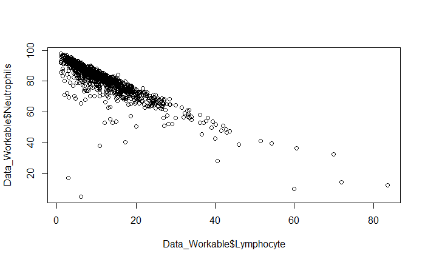

```r
              plot(x = Data_Workable$Lymphocyte, y = Data_Workable$Neutrophils)
              par(mfrow=c(1,3))
```

```r
          #Behavior
              hist(Data_Workable$`Lymphocyte`)
              qqnorm(Data_Workable$`Lymphocyte`)
```

```r
              qqline(Data_Workable$`Lymphocyte`)
              dens = density(Data_Workable$`Lymphocyte`, na.rm = TRUE)
              plot(dens, main ="Densidad de Lymp")
```

```r
              #Resp: Maybe Normal

          #Hyp. test
              resultsSW <- shapiro.test(Data_Workable$`Lymphocyte`);resultsSW
```

```
    Shapiro-Wilk normality test

data:  Data_Workable$Lymphocyte
W = 0.82034, p-value < 0.00000000000000022
```

```r
              resultsAD <- ad.test(Data_Workable$`Lymphocyte`);resultsAD
```

```
    Anderson-Darling normality test

data:  Data_Workable$Lymphocyte
A = 32.255, p-value < 0.00000000000000022
```

```r
              resultsKS <- ks.test(Data_Workable$`Lymphocyte`, "pnorm", mean(Data_Workable$`Lymphocyte`), sd(Data_Workable$`Lymphocyte`))
              #Non conclusive, no normal

          #Simple imputation: Median
              Data_Imputed$`Lymphocyte`[is.na(Data_Imputed$`Lymphocyte`)] <- median(Data_Imputed$`Lymphocyte`, na.rm = TRUE)
              summary(Data_Imputed$`Lymphocyte`)
```

```
   Min. 1st Qu.  Median    Mean 3rd Qu.    Max.
 0.9667  7.1000 10.4667 12.0150 14.7000 83.5000
```

```r
              summary(Data_Workable$`Lymphocyte`)
```

```
   Min. 1st Qu.  Median    Mean 3rd Qu.    Max.    NA's
 0.9667  6.6333 10.4667 12.2327 15.4750 83.5000     145
```

```r
                  ###1.2

      #12. PT----

          #20/1176
          #1.7%

          #Cor
              data_cor <- cor(Data_Workable[ , colnames(Data_Workable) != "PT"],Data_Workable$PT,use='complete.obs');data_cor
```

```
                                   [,1]
outcome                   0.21435583504
age                       0.10843938221
gendera                  -0.06259902019
BMI                       0.01000158343
hypertensive              0.02388074904
atrialfibrillation        0.30839089398
CHD_with_no_MI           -0.02621725788
diabetes                  0.03535575917
deficiencyanemias        -0.07975456602
depression               -0.04405744032
Hyperlipemia              0.13365048613
Renal_failure             0.03034310083
COPD                     -0.01512090356
heart_rate                0.02279570919
Systolic_blood_pressure  -0.12855281636
Diastolic_blood_pressure -0.02665538633
Respiratory_rate          0.06268022895
temperature              -0.11740295500
SP_O2                    -0.05222612871
Urine_output             -0.02156779193
hematocrit                0.06289302492
RBC                       0.08373948887
MCH                      -0.09947925672
MCHC                     -0.11054280691
MCV                      -0.05428685325
RDW                       0.10916771712
Leucocyte                 0.14143538459
Platelets                 0.00093039684
Neutrophils               0.06889487620
Basophils                -0.00958221261
Lymphocyte               -0.09121450046
INR                       0.99361137179
NT_proBNP                 0.03641327864
Creatine_kinase           0.12018555523
Creatinine                0.00709422852
Urea_nitrogen             0.05694196000
glucose                   0.00302335743
Blood_potassium           0.02477224652
Blood_sodium             -0.02347272352
Blood_calcium            -0.17225312369
Chloride                  0.03330688147
Anion_gap                 0.09408677447
Magnesium_ion             0.00006063636
PH                       -0.01730802624
Bicarbonate              -0.09064288888
Lactic_acid               0.16898401183
PCO2                     -0.03346066911
EF                       -0.05770995195
```

[figure not shown]

```r
              #Resp: Low for all, 0.99361137179 for INR

          #Graph by cor
              par(mfrow=c(1,1))
```

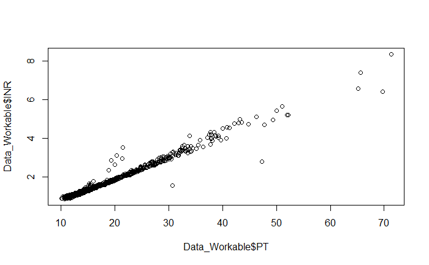

```r
              plot(x = Data_Workable$PT, y = Data_Workable$INR)
              par(mfrow=c(1,3))
```

```r
          #Behavior
              hist(Data_Workable$PT)
              qqnorm(Data_Workable$`PT`)
```

```r
              qqline(Data_Workable$`PT`)
              dens = density(Data_Workable$`PT`, na.rm = TRUE)
              plot(dens, main ="Densidad de PT")
```

```r
              #Resp: Maybe Normal

          #Hyp. test
              resultsSW <- shapiro.test(Data_Workable$`PT`);resultsSW
```

```
    Shapiro-Wilk normality test

data:  Data_Workable$PT
W = 0.71181, p-value < 0.00000000000000022
```

```r
              resultsAD <- ad.test(Data_Workable$`PT`);resultsAD
```

```
    Anderson-Darling normality test

data:  Data_Workable$PT
A = 101.54, p-value < 0.00000000000000022
```

```r
              resultsKS <- ks.test(Data_Workable$`PT`, "pnorm", mean(Data_Workable$`PT`), sd(Data_Workable$`PT`))
              #Non conclusive, not normal

          #Simple imputation: Median
              Data_Imputed$`PT`[is.na(Data_Imputed$`PT`)] <- median(Data_Imputed$`PT`, na.rm = TRUE)
              summary(Data_Imputed$`PT`)
```

```
   Min. 1st Qu.  Median    Mean 3rd Qu.    Max.
  10.10   13.20   14.64   17.44   18.69   71.27
```

```r
              summary(Data_Workable$`PT`)
```

```
   Min. 1st Qu.  Median    Mean 3rd Qu.    Max.    NA's
  10.10   13.16   14.64   17.49   18.80   71.27      20
```

```r
                   ###2.1

      #13. INR----

          #20/1176
          #1.7%

          #Cor
              data_cor <- cor(Data_Workable[ , colnames(Data_Workable) != "INR"],Data_Workable$INR, use='complete.obs');data_cor
```

```
                                 [,1]
outcome                   0.213597891
age                       0.109217747
gendera                  -0.065919839
BMI                       0.006856954
hypertensive              0.019426750
atrialfibrillation        0.291812709
CHD_with_no_MI           -0.029018898
diabetes                  0.035328429
deficiencyanemias        -0.073667437
depression               -0.050215114
Hyperlipemia              0.124687259
Renal_failure             0.026849262
COPD                     -0.010332637
heart_rate                0.016138901
Systolic_blood_pressure  -0.124543321
Diastolic_blood_pressure -0.027297043
Respiratory_rate          0.061655723
temperature              -0.116995368
SP_O2                    -0.064653228
Urine_output             -0.025232485
hematocrit                0.066253426
RBC                       0.089860841
MCH                      -0.099301795
MCHC                     -0.099158217
MCV                      -0.060434311
RDW                       0.109566971
Leucocyte                 0.129067428
Platelets                 0.001956007
Neutrophils               0.060521669
Basophils                -0.007485814
Lymphocyte               -0.088861610
PT                        0.993611372
NT_proBNP                 0.031947487
Creatine_kinase           0.113890925
Creatinine                0.007047621
Urea_nitrogen             0.056660691
glucose                  -0.003557547
Blood_potassium           0.031269549
Blood_sodium             -0.026488828
Blood_calcium            -0.171678791
Chloride                  0.031313393
Anion_gap                 0.090372925
Magnesium_ion            -0.002097956
PH                       -0.028521503
Bicarbonate              -0.088667363
Lactic_acid               0.162216211
PCO2                     -0.025563815
EF                       -0.049298334
```

[figure not shown]

```r
              #Resp: Low for all 0.993611372 for PT

          #Graph by Cor
              par(mfrow=c(1,1))
```

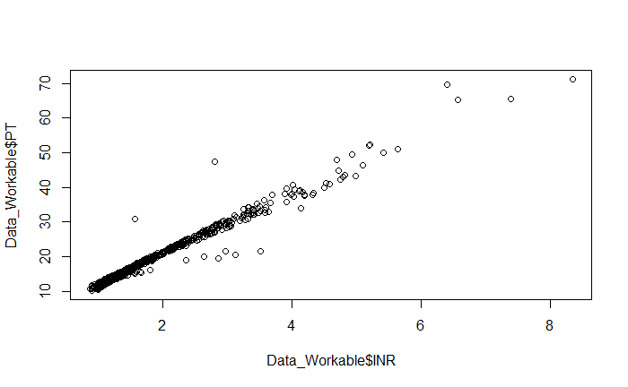

```r
              plot(x = Data_Workable$INR, y = Data_Workable$PT)
              par(mfrow=c(1,3))
```

```r
          #Behavior
              hist(Data_Workable$`INR`)
              qqnorm(Data_Workable$`INR`)
```

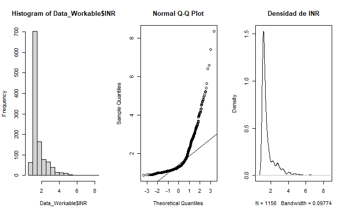

```r
              qqline(Data_Workable$`INR`)
              dens = density(Data_Workable$`INR`, na.rm = TRUE)
              plot(dens, main ="Densidad de INR")
```

```r
              #Resp: Maybe Normal

          #Hyp. test
              resultsSW <- shapiro.test(Data_Workable$`INR`);resultsSW
```

```
    Shapiro-Wilk normality test

data:  Data_Workable$INR
W = 0.69514, p-value < 0.00000000000000022
```

```r
              resultsAD <- ad.test(Data_Workable$`INR`);resultsAD
```

```
    Anderson-Darling normality test

data:  Data_Workable$INR
A = 111.02, p-value < 0.00000000000000022
```

```r
              resultsKS <- ks.test(Data_Workable$`INR`, "pnorm", mean(Data_Workable$`INR`), sd(Data_Workable$`INR`))
              #Non conclusive, no normal

          #Simple imputation: Median
              Data_Imputed$`INR`[is.na(Data_Imputed$`INR`)] <- median(Data_Imputed$`INR`, na.rm = TRUE)
              summary(Data_Imputed$`INR`)
```

```
   Min. 1st Qu.  Median    Mean 3rd Qu.    Max.
 0.8714  1.1429  1.3000  1.6205  1.7149  8.3429
```

```r
              summary(Data_Workable$`INR`)
```

```
   Min. 1st Qu.  Median    Mean 3rd Qu.    Max.    NA's
 0.8714  1.1400  1.3000  1.6261  1.7364  8.3429      20
```

```r
                  ###2.2

      #14. Creatine Kinase----

          #165/1176
          #14.03%

          #Cor
              data_cor <- cor(Data_Workable[ , colnames(Data_Workable) != "Creatine_kinase"],Data_Workable$Creatine_kinase, use='complete.obs');data_cor
```

```
                                  [,1]
outcome                   0.1118722223
age                      -0.0111701160
gendera                   0.0430333127
BMI                       0.0393529904
hypertensive              0.0479787863
atrialfibrillation        0.0193033278
CHD_with_no_MI           -0.0164231678
diabetes                  0.0766467978
deficiencyanemias        -0.0411195892
depression               -0.0283088127
Hyperlipemia             -0.0481059594
Renal_failure            -0.0252109525
COPD                     -0.0045495002
heart_rate                0.1152908163
Systolic_blood_pressure  -0.0245235349
Diastolic_blood_pressure -0.0458300414
Respiratory_rate          0.1377705801
temperature               0.1448974894
SP_O2                    -0.0366935474
Urine_output             -0.0320519985
hematocrit                0.0547309110
RBC                       0.0452065970
MCH                       0.0296158876
MCHC                      0.0328958203
MCV                       0.0172318501
RDW                      -0.0395183322
Leucocyte                 0.1027461878
Platelets                -0.0154319628
Neutrophils               0.0200149915
Basophils                 0.0005752962
Lymphocyte               -0.0486307580
PT                        0.1201855552
INR                       0.1138909252
NT_proBNP                -0.0212162768
Creatinine               -0.0051543521
Urea_nitrogen             0.0442390851
glucose                   0.1574844457
Blood_potassium           0.0442108479
Blood_sodium              0.0193748413
Blood_calcium            -0.0908127249
Chloride                  0.0572566654
Anion_gap                 0.0498952531
Magnesium_ion            -0.0125654087
PH                       -0.0237581774
Bicarbonate              -0.0591590676
Lactic_acid               0.1129473270
PCO2                     -0.0496020531
EF                       -0.1059288008
```

```r
              #Resp: Low for all

          #Behavior
              hist(Data_Workable$Creatine_kinase, breaks = 20)
              qqnorm(Data_Workable$Creatine_kinase)
```

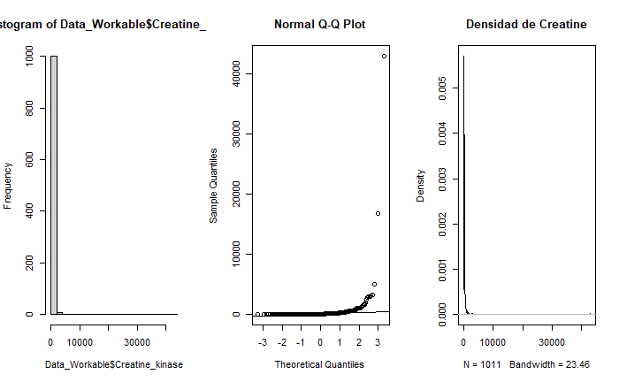

```r
              qqline(Data_Workable$Creatine_kinase)
              dens = density(Data_Workable$Creatine_kinase, na.rm = TRUE)
              plot(dens, main ="Densidad de Creatine")
```

```r
              #Resp: Maybe Normal

          #Hyp. test
              resultsSW <- shapiro.test(Data_Workable$Creatine_kinase);resultsSW
```

```
    Shapiro-Wilk normality test

data:  Data_Workable$Creatine_kinase
W = 0.078635, p-value < 0.00000000000000022
```

```r
              resultsAD <- ad.test(Data_Workable$Creatine_kinase);resultsAD
```

```
    Anderson-Darling normality test

data:  Data_Workable$Creatine_kinase
A = 295.38, p-value < 0.00000000000000022
```

```r
              resultsKS <- ks.test(Data_Workable$Creatine_kinase, "pnorm", mean(Data_Workable$Creatine_kinase), sd(Data_Workable$Creatine_kinase))
              #Non conclusive, not normal

          #Simple imputation: Median
              Data_Imputed$Creatine_kinase[is.na(Data_Imputed$Creatine_kinase)] <- median(Data_Imputed$Creatine_kinase, na.rm = TRUE)
              summary(Data_Imputed$Creatine_kinase)
```

```
   Min. 1st Qu.  Median    Mean 3rd Qu.    Max.
    8.0    51.0    89.5   224.8   162.4 42987.5
```

```r
              summary(Data_Workable$Creatine_kinase)
```

```
   Min. 1st Qu.  Median    Mean 3rd Qu.    Max.    NA's
    8.0    46.0    89.5   246.9   185.4 42987.5     165
```

```r
      #15. Glucose----

          #17/1176
          #1.44%

          #Cor
              data_cor <- cor(Data_Workable[ , colnames(Data_Workable) != "glucose"],Data_Workable$glucose, use='complete.obs');data_cor
```

```
                                 [,1]
outcome                   0.116124211
age                      -0.074568897
gendera                   0.042092957
BMI                       0.087586546
hypertensive              0.028357683
atrialfibrillation        0.017457495
CHD_with_no_MI            0.103856309
diabetes                  0.406242827
deficiencyanemias         0.001399866
depression                0.016042842
Hyperlipemia              0.118257614
Renal_failure            -0.028253277
COPD                     -0.077738841
heart_rate                0.104526846
Systolic_blood_pressure   0.008750940
Diastolic_blood_pressure  0.026522691
Respiratory_rate          0.064575337
temperature               0.077101082
SP_O2                     0.038642989
Urine_output             -0.029131849
hematocrit               -0.057642228
RBC                      -0.021940215
MCH                      -0.065482811
MCHC                     -0.022442741
MCV                      -0.066213188
RDW                      -0.005479695
Leucocyte                 0.111001299
Platelets                -0.019977482
Neutrophils               0.078285139
Basophils                -0.103510048
Lymphocyte               -0.066837928
PT                        0.003023357
INR                      -0.003557547
NT_proBNP                -0.048840810
Creatine_kinase           0.157484446
Creatinine               -0.012398151
Urea_nitrogen             0.095355317
Blood_potassium           0.058291622
Blood_sodium             -0.057935887
Blood_calcium            -0.069763614
Chloride                  0.016843749
Anion_gap                 0.082929522
Magnesium_ion             0.016736154
PH                        0.006772908
Bicarbonate              -0.093965910
Lactic_acid               0.220585224
PCO2                     -0.098689553
EF                       -0.003837201
```

```r
              #Resp: Low for all

          #Behavior
              hist(Data_Workable$`glucose`)
              qqnorm(Data_Workable$`glucose`)
```

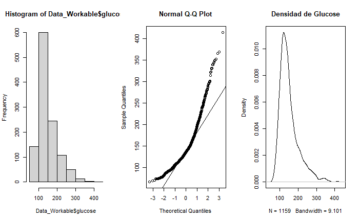

```r
              qqline(Data_Workable$`glucose`)
              dens = density(Data_Workable$`glucose`, na.rm = TRUE)
              plot(dens, main ="Densidad de Glucose")
```

```r
              #Resp: Maybe Normal

          #Hyp. test
              resultsSW <- shapiro.test(Data_Workable$`glucose`);resultsSW
```

```
    Shapiro-Wilk normality test

data:  Data_Workable$glucose
W = 0.88581, p-value < 0.00000000000000022
```

```r
              resultsAD <- ad.test(Data_Workable$`glucose`);resultsAD
```

```
    Anderson-Darling normality test

data:  Data_Workable$glucose
A = 36.732, p-value < 0.00000000000000022
```

```r
              resultsKS <- ks.test(Data_Workable$`glucose`, "pnorm", mean(Data_Workable$`glucose`), sd(Data_Workable$`glucose`))
              #Non conclusive, not normal

          #Simple imputation: Median
              Data_Imputed$`glucose`[is.na(Data_Imputed$`glucose`)] <- median(Data_Imputed$`glucose`, na.rm = TRUE)
              summary(Data_Imputed$`glucose`)
```

```
   Min. 1st Qu.  Median    Mean 3rd Qu.    Max.
  66.67  114.00  136.40  148.62  169.00  414.10
```

```r
              summary(Data_Workable$`glucose`)
```

```
   Min. 1st Qu.  Median    Mean 3rd Qu.    Max.    NA's
  66.67  113.94  136.40  148.80  169.50  414.10      17
```

```r
      #16. Blood Calcium----

          #1/1176
          #0.08%

          #Cor
              data_cor <- cor(Data_Workable[ , colnames(Data_Workable) != "Blood_calcium"],Data_Workable$Blood_calcium, use='complete.obs');data_cor
```

```
                                 [,1]
outcome                  -0.244309383
age                      -0.034885508
gendera                   0.090748018
BMI                       0.119075753
hypertensive              0.051792296
atrialfibrillation        0.040010246
CHD_with_no_MI           -0.055699361
diabetes                  0.025273221
deficiencyanemias        -0.100856683
depression                0.037263305
Hyperlipemia              0.057084163
Renal_failure             0.023755028
COPD                      0.083848916
heart_rate               -0.123803096
Systolic_blood_pressure   0.132845114
Diastolic_blood_pressure  0.169292219
Respiratory_rate         -0.056503138
temperature              -0.077769059
SP_O2                    -0.083216739
Urine_output              0.124722075
hematocrit                0.259122051
RBC                       0.239437168
MCH                      -0.041846982
MCHC                     -0.074942012
MCV                      -0.015761654
RDW                      -0.147812517
Leucocyte                -0.190439951
Platelets                 0.063709515
Neutrophils              -0.108823730
Basophils                 0.090501985
Lymphocyte                0.159951937
PT                       -0.172253124
INR                      -0.171678791
NT_proBNP                -0.175591651
Creatine_kinase          -0.090812725
Creatinine               -0.022240503
Urea_nitrogen            -0.066017032
glucose                  -0.069763614
Blood_potassium           0.005458594
Blood_sodium              0.049928390
Chloride                 -0.309457881
Anion_gap                -0.043072652
Magnesium_ion             0.002365846
PH                        0.132373934
Bicarbonate               0.340282732
Lactic_acid              -0.155427532
PCO2                      0.210934630
EF                        0.035231586
```

```r
              #Resp: Low for all

          #Behavior
              hist(Data_Workable$Blood_calcium)
              qqnorm(Data_Workable$Blood_calcium)
```

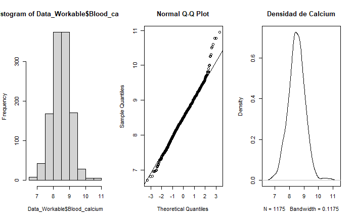

```r
              qqline(Data_Workable$Blood_calcium)
              dens = density(Data_Workable$Blood_calcium, na.rm = TRUE)
              plot(dens, main ="Densidad de Calcium")
```

```r
              #Resp: Maybe Normal

          #Hyp. test
              resultsSW <- shapiro.test(Data_Workable$Blood_calcium);resultsSW
```

```
    Shapiro-Wilk normality test

data:  Data_Workable$Blood_calcium
W = 0.99276, p-value = 0.00001655
```

```r
              resultsAD <- ad.test(Data_Workable$Blood_calcium);resultsAD
```

```
    Anderson-Darling normality test

data:  Data_Workable$Blood_calcium
A = 0.88744, p-value = 0.02325
```

```r
              resultsKS <- ks.test(Data_Workable$Blood_calcium, "pnorm", mean(Data_Workable$Blood_calcium), sd(Data_Workable$Blood_calcium))
              #Non conclusive, not normal

          #Simple imputation: Median
              Data_Imputed$Blood_calcium[is.na(Data_Imputed$Blood_calcium)] <- median(Data_Imputed$Blood_calcium, na.rm = TRUE)
              summary(Data_Imputed$Blood_calcium)
```

```
   Min. 1st Qu.  Median    Mean 3rd Qu.    Max.
  6.700   8.150   8.500   8.502   8.869  10.950
```

```r
              summary(Data_Workable$Blood_calcium)
```

```
   Min. 1st Qu.  Median    Mean 3rd Qu.    Max.    NA's
  6.700   8.150   8.500   8.502   8.869  10.950       1
```

```r
      #17. PH----

          #291/1176
          #24.74%

          #Cor
              data_cor <- cor(Data_Workable[ , colnames(Data_Workable) != "PH"],Data_Workable$PH, use='complete.obs');data_cor
```

```
                                 [,1]
outcome                  -0.174682474
age                       0.065578274
gendera                  -0.120674008
BMI                      -0.103250085
hypertensive             -0.031549361
atrialfibrillation        0.058224503
CHD_with_no_MI            0.035010220
diabetes                  0.003888509
deficiencyanemias         0.031593795
depression                0.102613669
Hyperlipemia              0.015360420
Renal_failure            -0.015949442
COPD                     -0.170774273
heart_rate                0.047841990
Systolic_blood_pressure   0.154348063
Diastolic_blood_pressure  0.156143070
Respiratory_rate          0.134751037
temperature               0.178753679
SP_O2                     0.041149789
Urine_output              0.205065209
hematocrit               -0.023256548
RBC                      -0.002390430
MCH                       0.040433831
MCHC                      0.169524071
MCV                      -0.050407922
RDW                      -0.106556471
Leucocyte                -0.012687950
Platelets                 0.157628817
Neutrophils               0.043300837
Basophils                 0.021054166
Lymphocyte               -0.010692240
PT                       -0.017308026
INR                      -0.028521503
NT_proBNP                -0.078890439
Creatine_kinase          -0.023758177
Creatinine               -0.208274644
Urea_nitrogen            -0.179442631
glucose                   0.006772908
Blood_potassium          -0.328042427
Blood_sodium             -0.104025238
Blood_calcium             0.132373934
Chloride                 -0.187450824
Anion_gap                -0.096713044
Magnesium_ion             0.001838833
Bicarbonate               0.130923778
Lactic_acid              -0.023434856
PCO2                     -0.391750576
EF                       -0.018441901
```

```r
              #Resp: Low for all

          #Behavior
              hist(Data_Workable$`PH`)
              qqnorm(Data_Workable$`PH`)
```

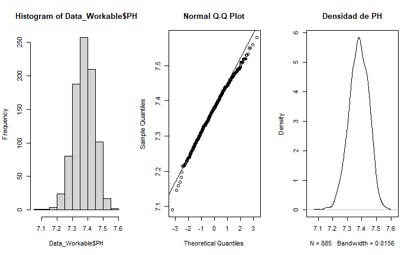

```r
              qqline(Data_Workable$`PH`)
              dens = density(Data_Workable$`PH`, na.rm = TRUE)
              plot(dens, main ="Densidad de PH")
```

```r
              #Resp: Maybe Normal

          #Hyp. test
              resultsSW <- shapiro.test(Data_Workable$`PH`);resultsSW
```

```
    Shapiro-Wilk normality test

data:  Data_Workable$PH
W = 0.99464, p-value = 0.003195
```

```r
              resultsAD <- ad.test(Data_Workable$`PH`);resultsAD
```

```
    Anderson-Darling normality test

data:  Data_Workable$PH
A = 0.82726, p-value = 0.0327
```

```r
              resultsKS <- ks.test(Data_Workable$`PH`, "pnorm", mean(Data_Workable$`PH`), sd(Data_Workable$`PH`))
              #Non conclusive, not normal

          #Simple imputation: Median
              Data_Imputed$`PH`[is.na(Data_Imputed$`PH`)] <- median(Data_Imputed$`PH`, na.rm = TRUE)
              summary(Data_Imputed$`PH`)
```

```
   Min. 1st Qu.  Median    Mean 3rd Qu.    Max.
  7.090   7.350   7.380   7.379   7.410   7.580
```

```r
              summary(Data_Workable$`PH`)
```

```
   Min. 1st Qu.  Median    Mean 3rd Qu.    Max.    NA's
  7.090   7.335   7.380   7.379   7.430   7.580     291
```

```r
      #18. Lactic Acid----

          #228/1176
          #19.38

          #Cor
              data_cor <- cor(Data_Workable[ , colnames(Data_Workable) != "Lactic_acid"],Data_Workable$Lactic_acid, use='complete.obs');data_cor
```

```
                                  [,1]
outcome                   0.2974937503
age                       0.0321043660
gendera                   0.0044804720
BMI                      -0.1155543707
hypertensive              0.0231927632
atrialfibrillation        0.0214499570
CHD_with_no_MI            0.0141914077
diabetes                 -0.0052521368
deficiencyanemias        -0.1565060684
depression               -0.0707088428
Hyperlipemia              0.0487120462
Renal_failure            -0.1497002664
COPD                     -0.0911219115
heart_rate                0.2534045709
Systolic_blood_pressure  -0.1452348982
Diastolic_blood_pressure  0.0713397399
Respiratory_rate          0.1425764768
temperature              -0.0027956444
SP_O2                     0.0896589883
Urine_output             -0.1303734969
hematocrit                0.1307176186
RBC                       0.1131234910
MCH                       0.0562337484
MCHC                      0.0854961608
MCV                       0.0227595827
RDW                       0.0227273303
Leucocyte                 0.3309114957
Platelets                -0.0931807904
Neutrophils               0.0063459576
Basophils                 0.0021410934
Lymphocyte               -0.0440062579
PT                        0.1689840118
INR                       0.1622162111
NT_proBNP                 0.1078661146
Creatine_kinase           0.1129473270
Creatinine                0.0008602986
Urea_nitrogen            -0.0316081888
glucose                   0.2205852235
Blood_potassium           0.0793960934
Blood_sodium             -0.1395762653
Blood_calcium            -0.1554275324
Chloride                  0.0519304820
Anion_gap                 0.4005348916
Magnesium_ion            -0.0706891493
PH                       -0.0234348556
Bicarbonate              -0.3248363583
PCO2                     -0.3261167988
EF                       -0.2203574101
```

```r
              #Resp: Low for all

          #Behavior
              hist(Data_Workable$Lactic_acid)
              qqnorm(Data_Workable$Lactic_acid)
```

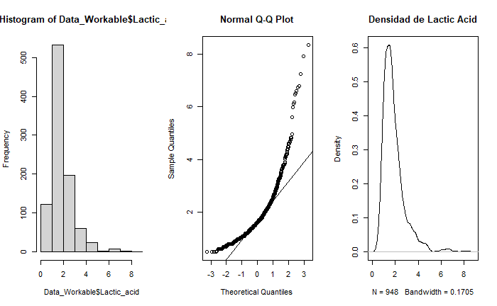

```r
              qqline(Data_Workable$Lactic_acid)
              dens = density(Data_Workable$Lactic_acid, na.rm = TRUE)
              plot(dens, main ="Densidad de Lactic Acid")
```

```r
              #Resp: Maybe Normal

          #Hyp. test
              resultsSW <- shapiro.test(Data_Workable$Lactic_acid);resultsSW
```

```
    Shapiro-Wilk normality test

data:  Data_Workable$Lactic_acid
W = 0.8199, p-value < 0.00000000000000022
```

```r
              resultsAD <- ad.test(Data_Workable$Lactic_acid);resultsAD
```

```
    Anderson-Darling normality test

data:  Data_Workable$Lactic_acid
A = 37.531, p-value < 0.00000000000000022
```

```r
              resultsKS <- ks.test(Data_Workable$Lactic_acid, "pnorm", mean(Data_Workable$Lactic_acid), sd(Data_Workable$Lactic_acid))
              #Non conclusive, not normal

          #Simple imputation: Median
              Data_Imputed$Lactic_acid[is.na(Data_Imputed$Lactic_acid)] <- median(Data_Imputed$Lactic_acid, na.rm = TRUE)
              summary(Data_Imputed$Lactic_acid)
```

```
   Min. 1st Qu.  Median    Mean 3rd Qu.    Max.
  0.500   1.300   1.600   1.804   2.002   8.333
```

```r
              summary(Data_Workable$Lactic_acid)
```

```
   Min. 1st Qu.  Median    Mean 3rd Qu.    Max.    NA's
  0.500   1.200   1.600   1.853   2.200   8.333     228
```

```r
      #19. PCO----

          #293/1176
          #24.91%

          #Cor
              data_cor <- cor(Data_Workable[ , colnames(Data_Workable) != "PCO2"],Data_Workable$PCO2, use='complete.obs');data_cor
```

```
                                [,1]
outcome                  -0.06096347
age                      -0.07108034
gendera                   0.11486311
BMI                       0.31521527
hypertensive             -0.02920712
atrialfibrillation       -0.09353926
CHD_with_no_MI           -0.06782804
diabetes                 -0.03315765
deficiencyanemias        -0.11759401
depression               -0.05793064
Hyperlipemia             -0.09040323
Renal_failure            -0.00571249
COPD                      0.27059609
heart_rate               -0.09047085
Systolic_blood_pressure   0.03084015
Diastolic_blood_pressure -0.02517028
Respiratory_rate         -0.06906291
temperature              -0.04888871
SP_O2                    -0.27038103
Urine_output              0.09984323
hematocrit                0.18360049
RBC                       0.13781760
MCH                      -0.07841987
MCHC                     -0.30136521
MCV                       0.07506374
RDW                       0.01577934
Leucocyte                -0.21164894
Platelets                -0.07979573
Neutrophils              -0.04027237
Basophils                 0.06472974
Lymphocyte                0.04469752
PT                       -0.03346067
INR                      -0.02556382
NT_proBNP                -0.17403153
Creatine_kinase          -0.04960205
Creatinine               -0.10080866
Urea_nitrogen            -0.09041339
glucose                  -0.09868955
Blood_potassium           0.06527506
Blood_sodium              0.29252832
Blood_calcium             0.21093463
Chloride                 -0.37733713
Anion_gap                -0.48133734
Magnesium_ion             0.08127064
PH                       -0.39175058
Bicarbonate               0.77257613
Lactic_acid              -0.32611680
EF                        0.14084138
```

```r
              #Resp: Low for all

          #Behavior
              hist(Data_Workable$`PCO2`)
              qqnorm(Data_Workable$`PCO2`)
```

```r
              qqline(Data_Workable$`PCO2`)
              dens = density(Data_Workable$`PCO2`, na.rm = TRUE)
              plot(dens, main ="Densidad de PCO")
```

```r
              #Resp: Maybe Normal

          #Hyp. test
              resultsSW <- shapiro.test(Data_Workable$`PCO2`);resultsSW
```

```
    Shapiro-Wilk normality test

data:  Data_Workable$PCO2
W = 0.9177, p-value < 0.00000000000000022
```

```r
              resultsAD <- ad.test(Data_Workable$`PCO2`);resultsAD
```

```
    Anderson-Darling normality test

data:  Data_Workable$PCO2
A = 21.059, p-value < 0.00000000000000022
```

```r
              resultsKS <- ks.test(Data_Workable$`PCO2`, "pnorm", mean(Data_Workable$`PCO2`), sd(Data_Workable$`PCO2`))
              #Non conclusive, not normal

          #Simple imputation: Median
              Data_Imputed$`PCO2`[is.na(Data_Imputed$`PCO2`)] <- median(Data_Imputed$`PCO2`, na.rm = TRUE)
              summary(Data_Imputed$`PCO2`)
```

```
   Min. 1st Qu.  Median    Mean 3rd Qu.    Max.
  18.75   39.00   43.00   44.90   47.28   98.60
```

```r
              summary(Data_Workable$`PCO2`)
```

```
   Min. 1st Qu.  Median    Mean 3rd Qu.    Max.    NA's
  18.75   37.04   43.00   45.54   50.59   98.60     293
```

[figure not shown]

```r
          par(mfrow=c(1,1))
```

```r
      Data_Factorized=Data_Imputed
```

## V.- Muestreo

Se realiza un muestreo para separar la base de datos en un set de entrenamiento y un set de prueba, con una proporcion de 70% y 30% respectivamente

```r
#----Subsets & Sampling----

      #1. Ratio of Outcome
          ratio = sum(Data_Factorized$outcome == 0) / sum(Data_Factorized$outcome == 1);ratio
```

```
[1] 6.396226
```

```r
      #2. Training and Prediction datasets proportions
          t_prop = 0.7
          p_prop = 0.3

      #3. Sampling Strategy
          set.seed(123)
          train_indices <- createDataPartition(Data_Factorized$outcome, p = t_prop, times = 1, list = FALSE)

      #4. Subsets
          Data_Training <- Data_Factorized[train_indices, ]
          Data_Prediction <- Data_Factorized[-train_indices, ]
          Backup_Data_Prediction <- Data_Prediction
```

## VI.- Modelos de Prediccion

Se entrenan multiples modelos de prediccion.

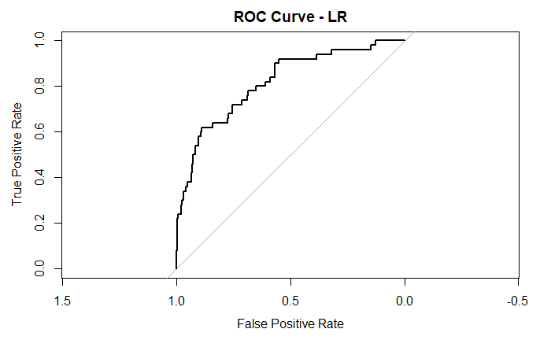

```r
#----Models----

      #1. Logistical Regression----

      #1.1  LR: Train & Save
          model_LR = glm(Data_Training$outcome ~ .,data = Data_Training, family = binomial)
          predictions_LR = predict(model_LR, newdata = Data_Prediction, type = "response")
          saveRDS(model_LR, "./model_LR.rda")

      #1.2 LR: Comparison
          Curve_Roc_LR = roc(Data_Prediction$outcome, predictions_LR)
          plot(Curve_Roc_LR, main = "ROC Curve - LR", xlab = "False Positive Rate", ylab = "True Positive Rate")
```

```r
          AUC_LR = Curve_Roc_LR$auc;AUC_LR
```

```
Area under the curve: 0.8164
```

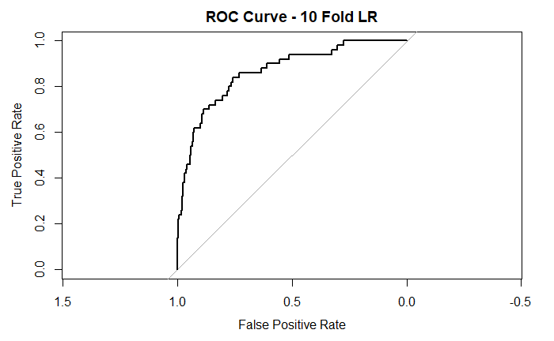

```r
      #1.3 LR: 10-Fold Cross Validation
          kfcv <- trainControl(method = "cv", number = 10)
          model_LR_kfcv <- train(outcome ~ ., data = Data_Imputed, method = "glm", trControl = kfcv, family = "binomial")
          predictions_LR_kfcv = predict(model_LR_kfcv, newdata = Data_Prediction)
          Curve_Roc_LR_kfcv = roc(Data_Prediction$outcome, predictions_LR_kfcv)
          plot(Curve_Roc_LR_kfcv, main = "ROC Curve - 10 Fold LR", xlab = "False Positive Rate", ylab = "True Positive Rate")
```

```r
          AUC_LR_kfcv = Curve_Roc_LR_kfcv$auc;AUC_LR_kfcv
```

```
Area under the curve: 0.8651
```

```r
          saveRDS(model_LR, "./model_LR_kfcv.rda")

      #2. XGBoost----

      #2.1  XGB: Data

          # Prepare the training data, separating predicting and outcome data
              X_train <- as.matrix(Data_Training[, !(colnames(Data_Training) %in% c("outcome"))])
              y_train <- Data_Training$outcome

          # Prepare the prediction data, separating predicting and outcome data
              X_pred <- as.matrix(Data_Prediction[, !(colnames(Data_Prediction) %in% c("outcome"))])
              y_pred <- Data_Prediction$outcome

          # Convert data into DMatrix objects
              train_dmatrix <- xgb.DMatrix(data = X_train, label = y_train)
              pred_dmatrix <- xgb.DMatrix(data = X_pred)

      #2.2 XGB: Parameters
            params <- list(
              objective = "binary:logistic",
              eval_metric = "logloss",
              max_depth = 3,
              eta = 0.1,
              nrounds = 100
            )

      #2.3 XGB: Train & Save
            model_XGB <- xgb.train(
              params = params,
              data = train_dmatrix,
              nrounds = params$nrounds,
              watchlist = list(train = train_dmatrix),
              verbose = 1
            )
```

```
[18:15:19] WARNING: src/learner.cc:767:
Parameters: { "nrounds" } are not used.
```

```r
            saveRDS(model_XGB, "./model_XGB.rda")

            predictions_XGB <- predict(model_XGB, newdata = pred_dmatrix);print(predictions_XGB)
```

[output not shown]

[output cut: 25 more lines]

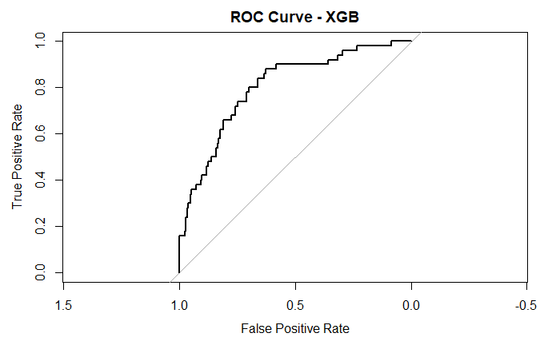

```r
            true_labels = Data_Prediction$outcome
            Curve_Roc_XGB <- roc(Data_Prediction$outcome, predictions_XGB)
            plot(Curve_Roc_XGB, main = "ROC Curve - XGB",xlab = "False Positive Rate", ylab = "True Positive Rate")
```

```r
            AUC_XGB <- auc(Curve_Roc_XGB);AUC_XGB
```

```
Area under the curve: 0.8016
```

```r
      #2.4 XGB: 10 Fold Cross Validation
            # model_XGB_kfcv <- xgb.cv(
            #   params = params,
            #   data = xgb.DMatrix(data = X_train, label = y_train),
            #   nfold = 10,
            #   stratified = TRUE,
            #   metrics = "logloss",
            #   early_stopping_rounds = 10,
            #   nrounds = 25,
            #   verbose = 1
            # )
            # saveRDS(model_XGB_kfcv, "./model_XGB_kfcv.rda")
            # predictions_XGB_kfcv <- predict(model_XGB_kfcv, newdata = pred_dmatrix);print(predictions)
            # Avg_LogLoss = mean(model_XGB_kfcv$evaluation_log$test_logloss_mean);Avg_LogLoss

      #3. Random Forest----

      #3.1 RF:  parameters
            num_trees = 1000
            features = sqrt(ncol(Data_Training))

      #3.2 RF: Train & Save
            model_RF = randomForest(outcome ~ ., data = Data_Training, ntree = num_trees, mtry = features);model_RF
```

```
Call:
 randomForest(formula = outcome ~ ., data = Data_Training, ntree = num_trees,      mtry = features)
               Type of random forest: regression
                     Number of trees: 1000
No. of variables tried at each split: 7

          Mean of squared residuals: 0.09173427
                    % Var explained: 20.08
```

```r
            saveRDS(model_RF, "./model_RF.rda")
            predictions_RF = predict(model_RF, newdata = Data_Prediction);predictions_RF
```

[output not shown]

[output cut: 17 more lines]

[output not shown]

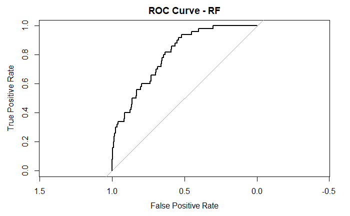

```r
            Curve_Roc_RF <- roc(Data_Prediction$outcome, predictions_RF)
            plot(Curve_Roc_RF, main = "ROC Curve - RF",xlab = "False Positive Rate", ylab = "True Positive Rate")
```

```r
            AUC_RF <- auc(Curve_Roc_RF);AUC_RF
```

```
Area under the curve: 0.7999
```

```r
      # #3.3 RF: 10 Fold Cross vlidation
      #
      #       ctrl = trainControl(method = "cv", number = 10, summaryFunction = twoClassSummary, classProbs = TRUE, verboseIter = FALSE)
      #       model_RF_kfcv <- train(outcome ~ ., data = Data_Training, method = "rf", trControl = ctrl, ntree = num_trees, mtry = features, metric = "RMSE");model_RF_kfcv
      #       saveRDS(model_RF, "./model_RF.rda")
      #       predictions_RF = predict(model_RF, newdata = Data_Prediction);predictions_RF
      #       Curve_Roc_RF <- roc(Data_Prediction$outcome, predictions_RF)
      #       plot(Curve_Roc_RF, main = "ROC Curve - RF",xlab = "False Positive Rate", ylab = "True Positive Rate")
      #       AUC_RF <- auc(Curve_Roc_RF);AUC_RF

      #4. Lasso

        #4.1  LS: Data

        # Prepare the training data, separating predicting and outcome data
        X_train <- as.matrix(Data_Training[, !(colnames(Data_Training) %in% c("outcome"))])
        y_train <- Data_Training$outcome

        # Prepare the prediction data, separating predicting and outcome data
        X_pred <- as.matrix(Data_Prediction[, !(colnames(Data_Prediction) %in% c("outcome"))])
        y_pred <- Data_Prediction$outcome

        #4.2 LS: Train & Save
        model_LS <- glmnet(X_train, y_train, alpha = 1)
        saveRDS(model_LS, "./model_LS.rda")

        #predictions_LS <- predict(model_LS, newx = X_pred)
        #Curve_Roc_LS <- roc(Data_Prediction$outcome, as.numeric(predictions_LS))
        #plot(Curve_Roc_LS, main = "ROC Curve - LS",xlab = "False Positive Rate", ylab = "True Positive Rate")
        #AUC_LS <- auc(Curve_Roc_LS);AUC_LS
```

## VII.- Shiny App

Se crea una solucion temporal para un producto basado en R Shiny, donde para este demo, se debe iniciar la aplicacion, y subir el archivo “test_pred.xlsx” ubicado en la carpeta “Data” del proyecto.

```r
library(shiny)
library(readxl)

# Load the pre-trained logistic regression model
model <- readRDS("model_LR_kfcv.rda")

ui <- fluidPage(
  sidebarLayout(
    sidebarPanel(
      fileInput("file", "Upload Excel file"),
      actionButton("submit", "Submit")
    ),
    mainPanel(
      tableOutput("output"),
      verbatimTextOutput("prediction")
    )
  )
)

server <- function(input, output) {
  data <- reactiveValues(df = NULL)

  observeEvent(input$submit, {
    req(input$file)

    # Read the uploaded Excel file
    df <- read_excel(input$file$datapath)

    # Make predictions using the data frame
    predictions <- predict(model, newdata = df, type = "response")

    # Display the predictions
    output$prediction <- renderPrint({
      paste("Predictions:", paste(predictions, collapse = ", "))
    })
  })

  output$output <- renderTable({
    data$df
  })
}

shinyApp(ui, server)
```

```
Listening on http://127.0.0.1:4095
```

```
NA
```